# Solar Radiation Transmittance formula

M. Marchildon

4/28/2020

## The Need

It is desirable to compute global radiation ($K_g$) using extraterrestrial solar radiation ($K_e$) approximated using solar irradiation theory and a combination readily available climate monitoring data such as temperatures and precipitation. While there are many methods to choose from (e.g., the Prescott-type equation; the Linacre (1992) equation; or the Hargreaves (1977; 1981) equations), the Bristow and Campbell (1984) relationship is chosen as it is flexible and relies on temperature data:

$$T_t = a\left[1 - e^{-b\Delta
T^c}\right]$$

where $T_t$ is transmittance, and $a$, $b$ and $c$ are empirical coefficients. $K_g$ is then approximated through the relationship:

$$K_g=T_tK_e$$

The coefficients $a$, $b$ and $c$ have somewhat different physical interpretations: $a$ is the maximum clear sky transmittance, and can vary from 0.6 in smoggy air to 0.9 clean air and clear skies (Oke, 1987). $b$ and $c$ determine how quickly $a$ is achieved with increasing $\Delta T$; Bristow and Campbell (1984) kept $c$ constant as $2.4$ and adjusted $b$ to fit data.

As evident from below, there is a great deal of scatter in such data. Bristow and Campbell (1984) offered 3 “fixes” to the input data, none of which appeared to reduce the scatter:

1. Set $\Delta T(j)=T_\text{max}(j) - 0.5\left(T_\text{min}(j)+T_\text{min}(j+1)\right)$ where $j$ is the day of observation. Here, Bristow and Campbell (1984) felt that relying on daily reported minimum and maximum temperatures caused some $\Delta T$ to be too excessive, and averaging the minimum temperatures before and after the daytime high helped reduce the noise. *This did not appear to here, based on visual observation and thus $\Delta T=T_\text{max} - T_\text{min}$ was used*;
2. On days with measured precipitation, set $T_t=0.75T_t$; and,
3. On days before a days with precipitation, where “$\Delta T(j-1)$ was less than $\Delta T(j-2)$ by more than 2°C”, set $T_t(j-1)=0.75T_t(j-1)$. This was to account for the assumption that cloud cover arrived a day before it rains on normally high-transmittance days.

## Validation

In replicating Figure 1 of Bristow and Campbell (1984), daily meteorological data from [UTMMS](https://www.utm.utoronto.ca/geography/resources/meteorological-station) between 1999 to 2010 was used, and a transmittance curve was visually fitted having the final parameter values of $a=0.75$, $b=0.0025$ and $c=2.5$:

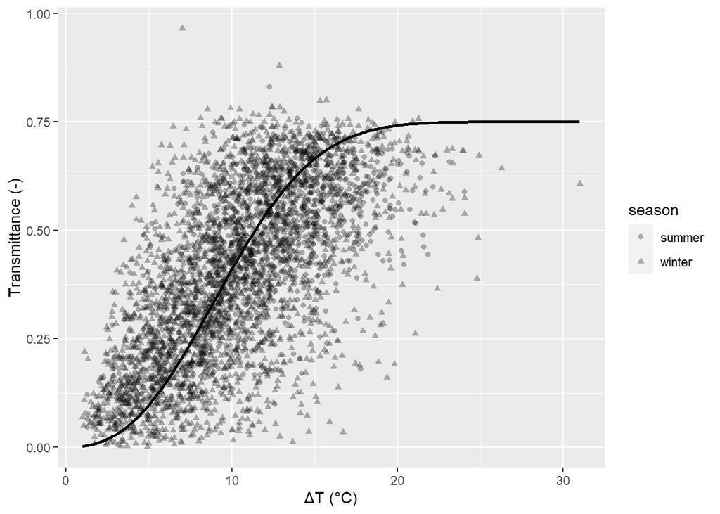

# References

Bristow, K.L. and G.S. Campbell, 1984. On the relationship between incoming solar radiation and daily maximum and minimum temperature. Agriculture and Forest Meteorology, 31: 159-66.

Hargreaves, G.H., 1977. World water for agriculture. Agency for international development, 177.

Hargreaves, G.H., 1981. Responding to tropical climates. The 1980-81 Food and Climate Review, The Food and Climate Forum, Aspen Institute for Humanistic Studies, Boulder, Colo., 29–32.

Linacre, E., 1992. Climate Data and Resources. London. Routledge.

Oke, T.R., 1987. Boundary Layer Climates, 2nd ed. London: Methuen, Inc.